# Developing an AI application

Going forward, AI algorithms will be incorporated into more and more everyday applications. For example, you might want to include an image classifier in a smart phone app. To do this, you'd use a deep learning model trained on hundreds of thousands of images as part of the overall application architecture. A large part of software development in the future will be using these types of models as common parts of applications.

In this project, you'll train an image classifier to recognize different species of flowers. You can imagine using something like this in a phone app that tells you the name of the flower your camera is looking at. In practice you'd train this classifier, then export it for use in your application. We'll be using [this dataset](http://www.robots.ox.ac.uk/~vgg/data/flowers/102/index.html) of 102 flower categories, you can see a few examples below.

[figure not shown]

The project is broken down into multiple steps:

- Load and preprocess the image dataset
- Train the image classifier on your dataset
- Use the trained classifier to predict image content

We'll lead you through each part which you'll implement in Python.

When you've completed this project, you'll have an application that can be trained on any set of labeled images. Here your network will be learning about flowers and end up as a command line application. But, what you do with your new skills depends on your imagination and effort in building a dataset. For example, imagine an app where you take a picture of a car, it tells you what the make and model is, then looks up information about it. Go build your own dataset and make something new.

First up is importing the packages you'll need. It's good practice to keep all the imports at the beginning of your code. As you work through this notebook and find you need to import a package, make sure to add the import up here.

Please make sure if you are running this notebook in the workspace that you have chosen GPU rather than CPU mode.

```python
# Imports here
%matplotlib inline
%config InlineBackend.figure_format = 'retina'

import numpy as np
import pandas as pd
import matplotlib.pyplot as plt

import torch
from torch import nn
from torch import optim
import torch.nn.functional as F
from torchvision import datasets, transforms, models
from torch.utils.data import DataLoader

import os
from random import randint
import time
from PIL import Image
import json
```

## Load the data

Here you'll use `torchvision` to load the data ([documentation](http://pytorch.org/docs/0.3.0/torchvision/index.html)). The data should be included alongside this notebook, otherwise you can [download it here](https://s3.amazonaws.com/content.udacity-data.com/nd089/flower_data.tar.gz). The dataset is split into three parts, training, validation, and testing. For the training, you'll want to apply transformations such as random scaling, cropping, and flipping. This will help the network generalize leading to better performance. You'll also need to make sure the input data is resized to 224x224 pixels as required by the pre-trained networks.

The validation and testing sets are used to measure the model's performance on data it hasn't seen yet. For this you don't want any scaling or rotation transformations, but you'll need to resize then crop the images to the appropriate size.

The pre-trained networks you'll use were trained on the ImageNet dataset where each color channel was normalized separately. For all three sets you'll need to normalize the means and standard deviations of the images to what the network expects. For the means, it's `[0.485, 0.456, 0.406]` and for the standard deviations `[0.229, 0.224, 0.225]`, calculated from the ImageNet images. These values will shift each color channel to be centered at 0 and range from -1 to 1.

```python
# Define the metavariables for the transforms
mean = [0.485, 0.456, 0.406]
std = [0.229, 0.224, 0.225]
crop_size = 224
max_size = 256
batch_size = 64

# Define the transforms on the data
data_dir = 'flowers'
loaders = ['train','valid','test']

loader_transforms = {
    loaders[0]:transforms.Compose([transforms.RandomRotation(30),
                                   transforms.RandomResizedCrop(crop_size),
                                   transforms.RandomHorizontalFlip(),
                                   transforms.ToTensor(),
                                   transforms.Normalize(mean, std)]),
    loaders[1]:transforms.Compose([transforms.Resize(max_size),
                                   transforms.CenterCrop(crop_size),
                                   transforms.ToTensor(),
                                   transforms.Normalize(mean, std)]),
    loaders[2]:transforms.Compose([transforms.Resize(max_size),
                                   transforms.CenterCrop(crop_size),
                                   transforms.ToTensor(),
                                   transforms.Normalize(mean, std)])
}

loader_datasets = {loader:datasets.ImageFolder(data_dir+'/'+loader, transform=loader_transforms[loader]) for loader in loaders}
dataloaders = {}
for loader in loaders:
    do_shuffle = (loader=='train')
    dataloaders[loader] = DataLoader(loader_datasets[loader], batch_size=batch_size, shuffle=do_shuffle)
```

### Label mapping

You'll also need to load in a mapping from category label to category name. You can find this in the file `cat_to_name.json`. It's a JSON object which you can read in with the [`json` module](https://docs.python.org/2/library/json.html). This will give you a dictionary mapping the integer encoded categories to the actual names of the flowers.

```python
with open('cat_to_name.json', 'r') as f:
    cat_to_name = json.load(f)
```

# Building and training the classifier

Now that the data is ready, it's time to build and train the classifier. As usual, you should use one of the pretrained models from `torchvision.models` to get the image features. Build and train a new feed-forward classifier using those features.

We're going to leave this part up to you. Refer to [the rubric](https://review.udacity.com/#!/rubrics/1663/view) for guidance on successfully completing this section. Things you'll need to do:

- Load a [pre-trained network](http://pytorch.org/docs/master/torchvision/models.html) (If you need a starting point, the VGG networks work great and are straightforward to use)
- Define a new, untrained feed-forward network as a classifier, using ReLU activations and dropout
- Train the classifier layers using backpropagation using the pre-trained network to get the features
- Track the loss and accuracy on the validation set to determine the best hyperparameters

We've left a cell open for you below, but use as many as you need. Our advice is to break the problem up into smaller parts you can run separately. Check that each part is doing what you expect, then move on to the next. You'll likely find that as you work through each part, you'll need to go back and modify your previous code. This is totally normal!

When training make sure you're updating only the weights of the feed-forward network. You should be able to get the validation accuracy above 70% if you build everything right. Make sure to try different hyperparameters (learning rate, units in the classifier, epochs, etc) to find the best model. Save those hyperparameters to use as default values in the next part of the project.

One last important tip if you're using the workspace to run your code: To avoid having your workspace disconnect during the long-running tasks in this notebook, please read in the earlier page in this lesson called Intro to GPU Workspaces about Keeping Your Session Active. You'll want to include code from the workspace_utils.py module.

```python
# Define the Classifier as a Class

class Network(nn.Module):
    def __init__(self, input_size, output_size, hidden_sizes, drop_rate=0.5):
        ''' Builds a flexible class to add arbitrary complexity to the classifier network.
            Inspired by Mat Leonard's example scripts
        '''
        super().__init__()

        # Add the first network layer
        self.hidden_sizes = nn.ModuleList([nn.Linear(input_size, hidden_sizes[0])])

        # Add an arbitrary amount of additional network layers
        layer_sizes = zip(hidden_sizes[:-1], hidden_sizes[1:])
        self.hidden_sizes.extend([nn.Linear(i, o) for i, o in layer_sizes])

        # Add the final network layer
        self.output = nn.Linear(hidden_sizes[-1], output_size)

        # Add the dropout rate
        self.dropout = nn.Dropout(p=drop_rate)

    def forward(self, x):
        ''' Forward pass through the network, returns the output information, must use this
            class based function as there is no built-in forward() method associated with
            nn.ModuleList().
        '''

        # Calculate the output of each layer and apply the activation function (ReLU), then perform the dropout
        for linear in self.hidden_sizes:
            x = F.relu(linear(x))
            x = self.dropout(x)

        x = self.output(x)

        # Softmax the results of the network as the result of this forward() method
        return F.log_softmax(x, dim=1)
```

```python
def set_active_device(device = 'cuda'):
    if (device == 'cuda') and torch.cuda.is_available():
        active_device = 'cuda'
    else:
        active_device = 'cpu'
    return active_device
```

```python
# Choose a pre-trained model and freeze the params
def load_model(modelname, hidden_sizes):
    if modelname == 'densenet121':
        model = models.densenet121(pretrained=True)
        model.name = 'densenet121'
        in_features = model.classifier.in_features
    elif modelname == 'densenet169':
        model = models.densenet169(pretrained=True)
        model.name = 'densenet169'
        in_features = model.classifier.in_features
    elif modelname == 'vgg16':
        model = models.vgg16(pretrained=True)
        model.name = 'vgg16'
        in_features = model.classifier[0].in_features
    # Freeze the params of the pretrained network
    for p in model.parameters():
        p.requires_grad = False
    classifier = Network(input_size=in_features, output_size=102, hidden_sizes=[1000,500], drop_rate=0.5)
    model.classifier = classifier

    return model
```

```python
# Load the model and set the classifier parameters
# Set the optimizer and loss function.
# Set the device on which to calculate

model = load_model('densenet169', [1000,500] )
#model = load_model('vgg16', [1000,500] )

model.class_to_idx = loader_datasets['train'].class_to_idx

criterion = nn.NLLLoss()
optimizer = optim.Adam(model.classifier.parameters(), lr=0.001)
active_device = set_active_device('cuda')
```

```python
# Implement a function for the validation pass
def validation(model, loader, criterion, device='cuda'):
    with torch.no_grad():
        test_loss = 0
        accuracy = 0
        start = time.time()
        model.eval()

        for images, classes in loader:
            images, classes = images.to(device), classes.to(device)
            #images.resize_(images.shape[0], 784)

            output = model.forward(images)
            test_loss += criterion(output, classes).item()

            ps = torch.exp(output)
            equality = (classes.data == ps.max(dim=1)[1])
            accuracy += equality.type(torch.FloatTensor).mean()
        test_loss *= 1/len(loader)
        accuracy *= 1/len(loader)
        report = "Test Loss: {:.4f} Test Accuracy: {:.4f}\n...it took {:.2f} to run the validation test".format(test_loss, accuracy, time.time()-start)

    return test_loss, accuracy, report
```

```python
def print_start_stats(name, device, epochs, batches, batchsize, lr, classifier):
    print("#"*50,
          "\nStarting Training with: {} on device: {}".format(name, device),
          "\n{} Epochs, {} batches, {} batchsize, {} learning rate\n".format(epochs, batches, batchsize, lr),
          "\n...and the Network looks like:\n{}\n".format(classifier),
          "#"*50
         )
    return
```

```python
def print_train_stats(e, epochs, batch, batch_quantity, batch_time, avg_loss, v_report, training_start):
    print("Epoch: {}/{} ".format(e, epochs),
          "Batch {}/{}".format(batch,batch_quantity),
          "Time per batch: {:.3f} seconds".format(batch_time),
          "\nTraining loss: {:.4f}".format(avg_loss),
          v_report,
          "\n",
          "{0} (runtime: {1:.1f}sec) {0}".format("#"*25, time.time()-training_start)
         )
    return
```

```python
def print_final_stats(model, device, epochs, lr, dataloaders, criterion, training_start):
    test_loss, accuracy, _ = validation(model, dataloaders['valid'], criterion, active_device)
    print("\n\n\nTrained with params:\nModel: {} Epochs: {} Batch Size: {} Learning Rate: {}".format(model.name, epochs, dataloaders['train'].batch_size, lr),
          "\nFINAL Validation Loss: {:.4f} Validation Accuracy: {:.4f}".format(test_loss, accuracy),
          "\n{0} \nTOTAL RUNTIME: {1:.2f} seconds\n{0}".format("#"*50, time.time()-training_start))
    return
```

```python
def train_classifier(model,
                     dataloaders,
                     optimizer,
                     criterion,
                     device='cuda',
                     epochs=3,
                     print_every=30,
                     test_run=None,
                     do_validation=None
                    ):
    '''Trains a model using a passed in classifier. The model, data, classifier network, and
       loss-function must be provided.
       All other parameters have default values but can be provided by the user for flexibility.
       Use 'test_run=X' where X is the number of batches to run through before quitting, for a quick test.
       Use 'do_validation=X' where X is a multiplier of the print_every variable, high numbers are less validation runs.
    '''

    batch_quantity = len(dataloaders['train'])
    lr = [p['lr'] for p in optimizer.param_groups][0]

    print_start_stats(model.name.upper(),
                      active_device.upper(),
                      epochs,
                      batch_quantity,
                      dataloaders['train'].batch_size,
                      lr,
                      model.classifier)

    model.to(device)
    model.train()
    accum_loss = 0
    training_start = batch_start = time.time()

    for e in range(epochs):

        for batch_num, (inputs, labels) in enumerate(dataloaders['train']):
            inputs, labels = inputs.to(device), labels.to(device)

            optimizer.zero_grad()

            #do the training
            outputs = model.forward(inputs)
            loss = criterion(outputs, labels)
            loss.backward()
            optimizer.step()

            accum_loss += loss.item()

            # Stats reporting
            if (batch_num+1) % print_every == 0:
                batch_time = (time.time() - batch_start)/print_every
                avg_loss = accum_loss/print_every
                v_report = ''

                # Validation code
                if (do_validation != None) and ((batch_num+1) % (print_every * do_validation) == 0):
                    test_loss, accuracy, v_report = validation(model, dataloaders['valid'], criterion, active_device)
                    model.train()

                print_train_stats(e+1, epochs, batch_num+1, batch_quantity, batch_time, avg_loss, v_report, training_start)

                accum_loss = 0
                batch_start = time.time()


            if (test_run is not None) and (batch_num==test_run):
                break



    print_final_stats(model, active_device, epochs, lr, dataloaders, criterion, training_start)

    model.optimizer_state = optimizer.state_dict()
    model.classifier.epochs = epochs
    model.lr = lr

    return model
```

```python
# TEST TRAINING
# uses the test_runs flag for short runthroughs
model = train_classifier(model,
                         dataloaders=dataloaders,
                         optimizer=optimizer,
                         criterion=criterion,
                         device=active_device,
                         epochs=1,
                         print_every=3,
                         test_run=60,
                         do_validation=5)
```

[output not shown]

```python
# DO REAL TRAINING
# trains the model to high fidelity

##########################
#INSTRUCTOR: PLEASE NOTE #
##########################
# The validation loss and Accuracy ARE displayed, as an option, but not every report,
# because the validation run-through is expensive. The parameters could be set to report
# training loss less regularly and the validation to report every time training loss is
# reported, that would just require parameters like:
# print_every=20, do_validation=1.
# Currently I want to see train loss regularly but only validate occasionally.

model = train_classifier(model,
                         dataloaders=dataloaders,
                         optimizer=optimizer,
                         criterion=criterion,
                         device=active_device,
                         epochs=10,
                         print_every=3,
                         do_validation=10)
```

```
##################################################
Starting Training with: DENSENET169 on device: CUDA
10 Epochs, 103 batches, 64 batchsize, 0.001 learning rate

...and the Network looks like:
Network(
  (hidden_sizes): ModuleList(
    (0): Linear(in_features=1664, out_features=1000, bias=True)
    (1): Linear(in_features=1000, out_features=500, bias=True)
  )
  (output): Linear(in_features=500, out_features=102, bias=True)
  (dropout): Dropout(p=0.5)
)
 ##################################################
Epoch: 1/10  Batch 3/103 Time per batch: 0.434 seconds
Training loss: 4.6318
 ######################### (runtime: 4.0sec) #########################
Epoch: 1/10  Batch 6/103 Time per batch: 0.430 seconds
Training loss: 4.6086
 ######################### (runtime: 7.9sec) #########################
Epoch: 1/10  Batch 9/103 Time per batch: 0.433 seconds
Training loss: 4.6075
 ######################### (runtime: 11.8sec) #########################
Epoch: 1/10  Batch 12/103 Time per batch: 0.418 seconds
Training loss: 4.5086
 ######################### (runtime: 15.6sec) #########################
Epoch: 1/10  Batch 15/103 Time per batch: 0.433 seconds
Training loss: 4.6715
 ######################### (runtime: 19.4sec) #########################
Epoch: 1/10  Batch 18/103 Time per batch: 0.429 seconds
Training loss: 4.5103
 ######################### (runtime: 23.3sec) #########################
Epoch: 1/10  Batch 21/103 Time per batch: 0.425 seconds
Training loss: 4.5582
 ######################### (runtime: 27.2sec) #########################
Epoch: 1/10  Batch 24/103 Time per batch: 0.421 seconds
Training loss: 4.4844
 ######################### (runtime: 31.0sec) #########################
Epoch: 1/10  Batch 27/103 Time per batch: 0.421 seconds
Training loss: 4.3797
```

[output cut: 1018 more lines]

```
Epoch: 10/10  Batch 99/103 Time per batch: 0.417 seconds
Training loss: 0.7694
 ######################### (runtime: 1785.8sec) #########################
Epoch: 10/10  Batch 102/103 Time per batch: 0.411 seconds
Training loss: 0.7113
 ######################### (runtime: 1789.5sec) #########################



Trained with params:
Model: densenet169 Epochs: 10 Batch Size: 64 Learning Rate: 0.001
FINAL Validation Loss: 0.2850 Validation Accuracy: 0.9236
##################################################
TOTAL RUNTIME: 1807.08 seconds
##################################################
```

## Testing your network

It's good practice to test your trained network on test data, images the network has never seen either in training or validation. This will give you a good estimate for the model's performance on completely new images. Run the test images through the network and measure the accuracy, the same way you did validation. You should be able to reach around 70% accuracy on the test set if the model has been trained well.

```python
# Run the trained model through the test dataset for fidelity checking
def test_model_results(model, dataloaders, criterion, device='cuda'):

    model.eval()
    model.to(device)
    with torch.no_grad():
        accuracy = 0
        for inputs, labels in dataloaders['test']:
                inputs, labels = inputs.to(device), labels.to(device)
                # Run the test data through the model
                outputs = model.forward(inputs)
                loss = criterion(outputs, labels)

                ps = torch.exp(outputs)
                equality = (labels.data == ps.max(dim=1)[1])
                accuracy = equality.type(torch.FloatTensor).mean()
                accuracy = accuracy.numpy()


                print(f'Loss: {loss.item():.3f}, Accuracy: {accuracy}')
```

```python
test_model_results(model, dataloaders, criterion)
```

```
Loss: 0.362, Accuracy: 0.921875
Loss: 0.313, Accuracy: 0.875
Loss: 0.291, Accuracy: 0.90625
Loss: 0.720, Accuracy: 0.796875
Loss: 0.148, Accuracy: 0.953125
Loss: 0.279, Accuracy: 0.921875
Loss: 0.075, Accuracy: 0.96875
Loss: 0.395, Accuracy: 0.90625
Loss: 0.059, Accuracy: 1.0
Loss: 0.123, Accuracy: 0.96875
Loss: 0.242, Accuracy: 0.953125
Loss: 0.493, Accuracy: 0.84375
Loss: 0.458, Accuracy: 0.8235294222831726
```

## Save the checkpoint

Now that your network is trained, save the model so you can load it later for making predictions. You probably want to save other things such as the mapping of classes to indices which you get from one of the image datasets: `image_datasets['train'].class_to_idx`. You can attach this to the model as an attribute which makes inference easier later on.

`model.class_to_idx = image_datasets['train'].class_to_idx`

Remember that you'll want to completely rebuild the model later so you can use it for inference. Make sure to include any information you need in the checkpoint. If you want to load the model and keep training, you'll want to save the number of epochs as well as the optimizer state, `optimizer.state_dict`. You'll likely want to use this trained model in the next part of the project, so best to save it now.

```python
def save_model(model, savename):
    '''
        Pass in a model with the appropriate sub attributes and a filepath for saving.
        Requires these to be defined in the model:
        model.optimizer_sate
        model.classifier.epochs
    '''

    model_state_name = savename

    checkpoint = {'arch': model.name,
                  'class_to_idx': model.class_to_idx,
                  'input_size': model.classifier.hidden_sizes[0].in_features,
                  'output_size': model.classifier.output.out_features,
                  'hidden_layers': [layer.out_features for layer in model.classifier.hidden_sizes],
                  'drop_rate': model.classifier.dropout.p,
                  'epochs': model.classifier.epochs,
                  'state_dict': model.state_dict(),
                  'optimizer': model.optimizer_state,
                  'lr':model.lr}
    model.to('cpu')
    torch.save(checkpoint, model_state_name)
    return True
```

```python
save_model(model, 'checkpoint_densenet169_v2.pth')
```

```
True
```

## Loading the checkpoint

At this point it's good to write a function that can load a checkpoint and rebuild the model. That way you can come back to this project and keep working on it without having to retrain the network.

```python
# TODO: Write a function that loads a checkpoint and rebuilds the model
def load_checkpoint(filepath):
    '''Loads a checkpoint from an earlier trained model.
        Requires these custom sub-attributes to be present in the save file:
        arch
        optimizer
        epochs
    '''
    checkpoint = torch.load(filepath, map_location=lambda storage, loc: storage)
    classifier = Network(checkpoint['input_size'],
                         checkpoint['output_size'],
                         checkpoint['hidden_layers'],
                         checkpoint['drop_rate']
                        )
    if checkpoint['arch'] == 'densenet121':
        model = models.densenet121(pretrained=True)
        model.name = checkpoint['arch']
    elif checkpoint['arch'] == 'densenet169':
        model = models.densenet169(pretrained=True)
        model.name = checkpoint['arch']
    else:
        print("Sorry, this checkpoint asks for a model that isn't supported!".format(checkpoint['arch']))

    model.epochs = checkpoint['epochs']
    model.classifier = classifier
    model.class_to_idx = checkpoint['class_to_idx']
    model.load_state_dict(checkpoint['state_dict'])
    optimizer = optim.Adam(model.classifier.parameters(), lr=0.001)
    optimizer.load_state_dict(checkpoint['optimizer'])
    return model
```

```python
model_path = 'checkpoint_densenet169_v2.pth'
model = load_checkpoint(model_path)
```

# Inference for classification

Now you'll write a function to use a trained network for inference. That is, you'll pass an image into the network and predict the class of the flower in the image. Write a function called `predict` that takes an image and a model, then returns the top $K$ most likely classes along with the probabilities. It should look like

```
probs, classes = predict(image_path, model)
print(probs)
print(classes)
> [ 0.01558163  0.01541934  0.01452626  0.01443549  0.01407339]
> ['70', '3', '45', '62', '55']
```

First you'll need to handle processing the input image such that it can be used in your network.

## Image Preprocessing

You'll want to use `PIL` to load the image ([documentation](https://pillow.readthedocs.io/en/latest/reference/Image.html)). It's best to write a function that preprocesses the image so it can be used as input for the model. This function should process the images in the same manner used for training.

First, resize the images where the shortest side is 256 pixels, keeping the aspect ratio. This can be done with the [`thumbnail`](http://pillow.readthedocs.io/en/3.1.x/reference/Image.html#PIL.Image.Image.thumbnail) or [`resize`](http://pillow.readthedocs.io/en/3.1.x/reference/Image.html#PIL.Image.Image.thumbnail) methods. Then you'll need to crop out the center 224x224 portion of the image.

Color channels of images are typically encoded as integers 0-255, but the model expected floats 0-1. You'll need to convert the values. It's easiest with a Numpy array, which you can get from a PIL image like so `np_image = np.array(pil_image)`.

As before, the network expects the images to be normalized in a specific way. For the means, it's `[0.485, 0.456, 0.406]` and for the standard deviations `[0.229, 0.224, 0.225]`. You'll want to subtract the means from each color channel, then divide by the standard deviation.

And finally, PyTorch expects the color channel to be the first dimension but it's the third dimension in the PIL image and Numpy array. You can reorder dimensions using [`ndarray.transpose`](https://docs.scipy.org/doc/numpy-1.13.0/reference/generated/numpy.ndarray.transpose.html). The color channel needs to be first and retain the order of the other two dimensions.

```python
def process_image(path, mean=[0.485, 0.456, 0.406], std=[0.229, 0.224, 0.225], crop_size=224, max_size=256):
    ''' Scales, crops, and normalizes a PIL image for a PyTorch model,
        returns an Numpy array
    '''

    # Process a PIL image for use in a PyTorch model
    with Image.open(path) as img:
        width, height = img.size
        if height > width:
            height = max_size * (height/width)
            width = max_size
        else:
            width = max_size * (width/height)
            height = max_size
        img = img.resize((int(width),int(height)))

        x = width/2-(crop_size/2)
        y = height/2-(crop_size/2)
        r = width/2+(crop_size/2)
        t = height/2+(crop_size/2)
        img = img.crop((x,y,r,t))

        img = np.array(img)/255
        img = (img - mean) / std
        img = img.transpose(2,0,1)
    return img
```

To check your work, the function below converts a PyTorch tensor and displays it in the notebook. If your `process_image` function works, running the output through this function should return the original image (except for the cropped out portions).

```python
def imshow(image, ax=None, title=None):
    if ax is None:
        fig, ax = plt.subplots()

    # PyTorch tensors assume the color channel is the first dimension
    # but matplotlib assumes is the third dimension
    image = image.transpose((1, 2, 0))

    # Undo preprocessing
    mean = np.array([0.485, 0.456, 0.406])
    std = np.array([0.229, 0.224, 0.225])
    image = std * image + mean

    # Image needs to be clipped between 0 and 1 or it looks like noise when displayed
    image = np.clip(image, 0, 1)

    ax.imshow(image)

    return ax
```

```python
def get_idx_label(idx):
    '''Returns the name of the flower, given an index.
    '''
    return cat_to_name[str(idx)]
```

## Class Prediction

Once you can get images in the correct format, it's time to write a function for making predictions with your model. A common practice is to predict the top 5 or so (usually called top-$K$) most probable classes. You'll want to calculate the class probabilities then find the $K$ largest values.

To get the top $K$ largest values in a tensor use [`x.topk(k)`](http://pytorch.org/docs/master/torch.html#torch.topk). This method returns both the highest `k` probabilities and the indices of those probabilities corresponding to the classes. You need to convert from these indices to the actual class labels using `class_to_idx` which hopefully you added to the model or from an `ImageFolder` you used to load the data (see here). Make sure to invert the dictionary so you get a mapping from index to class as well.

Again, this method should take a path to an image and a model checkpoint, then return the probabilities and classes.

```
probs, classes = predict(image_path, model)
print(probs)
print(classes)
> [ 0.01558163  0.01541934  0.01452626  0.01443549  0.01407339]
> ['70', '3', '45', '62', '55']
```

```python
def print_prediction_results(df, flower_label):
    print("{0}\n{1}\n{0}".format("#"*40, df))

    top_flower = df.index[0]
    if top_flower.lower() == flower_label.lower():
        match_status = "MATCHES"
    else:
        match_status = "DOESN'T match. Better luck next time"
    print(" {} was predicted by the model, and...\n".format(top_flower.upper()),
          "{} is the actual flower name.\n".format(flower_label.upper()),
          "This {}!".format(match_status))
    return
```

```python
def get_random_flower_path(basepath):
    flowers = []
    for path, folders, files in os.walk(basepath):
        for file in files:
            flowers.append(os.path.join(path,file))
    return flowers[randint(0,len(flowers)-1)]
```

```python
def predict(image_path, model, active_device='cuda', topk=5):
    ''' Predict the class (or classes) of an image using a trained deep learning model.
    '''

    # TODO: Implement the code to predict the class from an image file
    model.eval()
    #model.to(active_device)

    image = process_image(image_path)
    image = torch.from_numpy(image).type(torch.FloatTensor)
    #image.to(active_device)
    image.unsqueeze_(0)

    with torch.no_grad():
        output = model.forward(image)

    top_probs, top_classes = torch.topk(output, topk)

    top_probs = torch.exp(top_probs).data.numpy()[0]
    top_classes = top_classes.data.numpy()[0]

    invert_idx = {v:k for k,v in model.class_to_idx.items()}
    indexes = [invert_idx[c] for c in top_classes]
    labels = [get_idx_label(idx).title() for idx in indexes]
    classes = [int(x) for x in top_classes]
    probs = [int(x*10000)/10000 for x in top_probs]
    df = pd.DataFrame(np.array([classes, probs]).transpose(1,0), index=labels, columns=['model class','probability'])
    return df
```

```python
def check_flower_prediction(path, model, verbose=False):
    '''Takes the path to a flower, the path to the desired pre-trained model, and returns predictions.
        Use "verbose=True" to report additional information from the prediction model.
    '''
    df = predict(path, model)

    flower_class = path.split('/')[-2]
    flower_label = get_idx_label(flower_class)

    fig, (flower_image, data_graph) = plt.subplots(figsize=(4,8), nrows=2)

    # Set params for flower plot
    flower_image.set_xticks([])
    flower_image.set_yticks([])
    flower_image.set_title(flower_label)
    imshow(process_image(path),ax=flower_image)

    # Set params for data plot

    df = df.sort_values(by='probability')
    df['probability'].plot(kind='barh', ax=data_graph)
    num_ticks = 5
    tick = df['probability'].max()/num_ticks
    xticks = np.arange(0,tick*(num_ticks+1),tick)
    plt.xticks(xticks, rotation = 45)

    plt.show()

    if verbose:
        print(df.sort_values(by='probability', ascending=False))

    return
```

## Sanity Checking

Now that you can use a trained model for predictions, check to make sure it makes sense. Even if the testing accuracy is high, it's always good to check that there aren't obvious bugs. Use `matplotlib` to plot the probabilities for the top 5 classes as a bar graph, along with the input image. It should look like this:

[figure not shown]

You can convert from the class integer encoding to actual flower names with the `cat_to_name.json` file (should have been loaded earlier in the notebook). To show a PyTorch tensor as an image, use the `imshow` function defined above.

```python
# Enable either 'path' variable below to either use a specific image, or a randomly selected one

path = get_random_flower_path('flowers/')
#path = 'flowers/test/11/image_03151.jpg'

flower_class = path.split('/')[-2]
flower_label = get_idx_label(flower_class)
```

```python
#CLASS PREDICTION

df = predict(path, model)
df
```

|  | model class | probability |
| --- | --- | --- |
| Colt'S Foot | 6.0 | 0.9818 |
| Blanket Flower | 2.0 | 0.0088 |
| Common Dandelion | 48.0 | 0.0070 |
| Purple Coneflower | 11.0 | 0.0007 |
| Spear Thistle | 8.0 | 0.0006 |

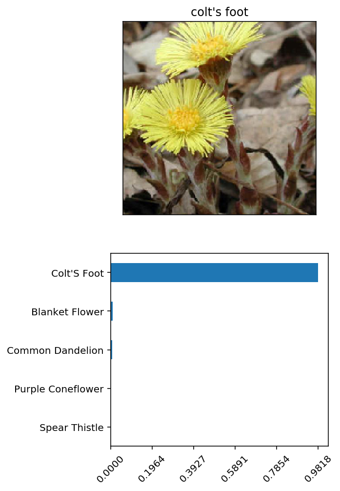

```
                   model class  probability
Colt'S Foot                6.0       0.9818
Blanket Flower             2.0       0.0088
Common Dandelion          48.0       0.0070
Purple Coneflower         11.0       0.0007
Spear Thistle              8.0       0.0006
```

```python
# SANITY CHECKING WITH MATPLOTLIB

check_flower_prediction(path, model,verbose=True)
```

```python
# COMPARE AND REPORT ON RESULTS

print_prediction_results(df, flower_label)
```

```
########################################
                   model class  probability
Colt'S Foot                6.0       0.9818
Blanket Flower             2.0       0.0088
Common Dandelion          48.0       0.0070
Purple Coneflower         11.0       0.0007
Spear Thistle              8.0       0.0006
########################################
 COLT'S FOOT was predicted by the model, and...
 COLT'S FOOT is the actual flower name.
 This MATCHES!
```